# act_report

## Analysis and Visualization

- This process is the final step ,when the wrangling has been carried out using the Data gathering, Assesement and Datacleaning.
- The cleaned master DataFrame was stored in a CSV file named twitter_archive_master.csv, which was used to generate insights and visualization into the dataset.
- df_merged.to_csv('twitter_archive_master.csv')

## Visualization

for the act_report, the relevant libraries were imported in order to carryout the visualization of the twitter_archive_master.csv dataset.

- For Visualization we will check the correlation between the favorite_count and the retweet count

```python
import pandas as pd
import numpy as np
import matplotlib.pyplot as plt
import seaborn as sns
```

```python
df_merged = pd.read_csv('twitter_archive_master.csv')
```

```
[Text(0.5, 1.0, 'Favorite Count against Retweet Count')]
```

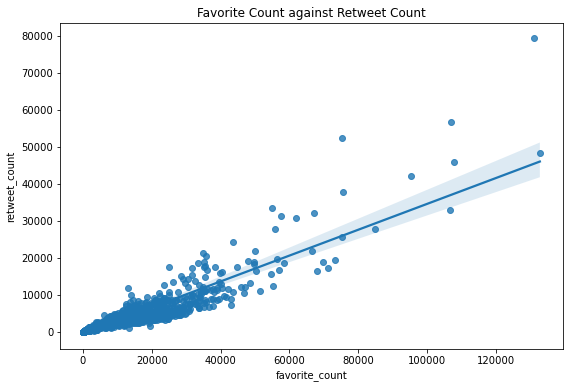

```python
#Display correlation between favorite count and retweet count
plt.figure(figsize= (9,6))
sns.regplot(x="favorite_count", y="retweet_count", data= df_merged).set(title = 'Favorite Count against Retweet Count')
```

From the scatter plot as shown above,there is a positive correlation of 0.9130 between the favorite_count and the retweet_count. It is observed that the dots are concentrated around the line from 0 to around 60000 for favorite count ,showing that the relationship between the favorite and retweet count is strong, hence the retweet counts tends to increase as the favorite count increases but as you move further ie greater than 60000 one would observe that there is a weak correlation as the dots become less concentrated and farther from the line.

## insights

- From the twitter_archive_master.csv dataset, it was observed that majority of the tweets were from iphones having as much as 1900 tweets followed by Web Client with less than a 100 counts while the least was from the tweetDeck whose count almost 0

```
[Text(0.5, 1.0, 'Tweet Source against Count')]
```

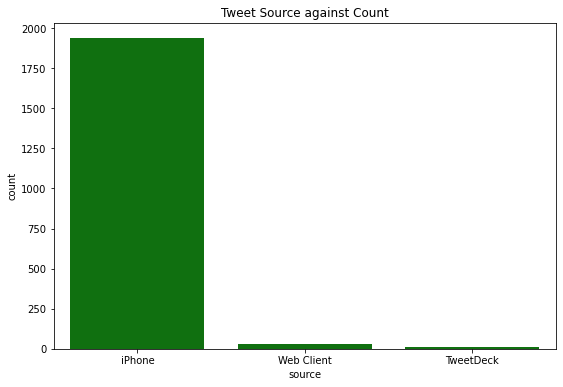

```python
#Display the most used twitter source?
plt.figure(figsize= (9,6))
sns.set_palette('dark')
sns.countplot(data=df_merged, x= 'source', color='g').set (Title = 'Tweet Source against Count')
```

```
[Text(0.5, 1.0, 'dog_stage against Count')]
```

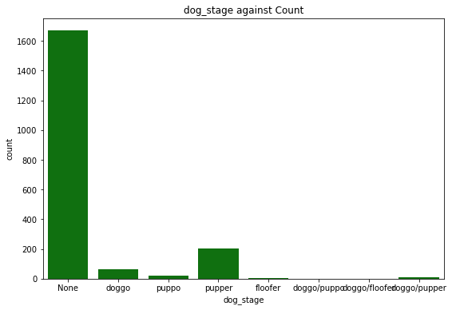

```python
#Display the dog_stage with the most retweet count
plt.figure(figsize= (9,6))
sns.set_palette('dark')
sns.countplot(data=df_merged, x= 'dog_stage', color='g').set (Title = 'dog_stage against Count')
```

- From the figure above, we are trying to see the count of each dog _stage,it was observed that majority of the dogs ie over 1600 had no dog stage,over 200 was pupper, followed by doggo with around 50 and puppo with around 10 ,doggo/puper with around 5 and floofer almost 0. there was no dog stage for the doggo/puppo and doggle/floofer. The dog stage with the most count with the exception of none is pupper.

```
[Text(0.5, 1.0, 'dog_stage against retweet_Count')]
```

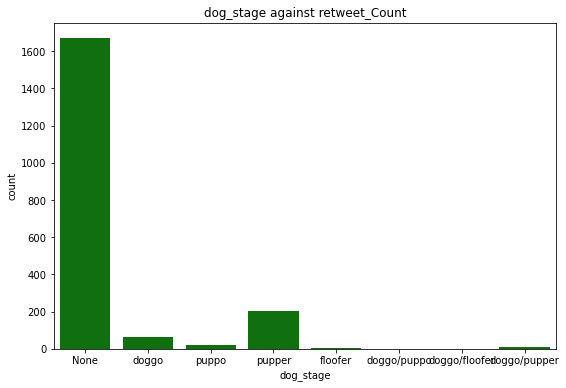

```python
#Display the dog_stage with the most retweet count
plt.figure(figsize= (9,6))
sns.set_palette('dark')
sns.countplot(data=df_merged, x= 'dog_stage', color='g').set (Title = 'dog_stage against retweet_Count')
```

```
[Text(0.5, 1.0, 'rating_numerator against count')]
```

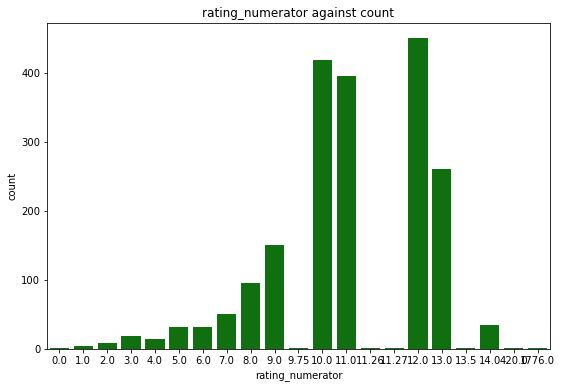

```python
# count of rating_numerator
plt.figure(figsize= (9,6))
sns.set_palette('dark')
sns.countplot(data=df_merged, x= 'rating_numerator', color='g').set (Title = 'rating_numerator against count')
```

- from the above representation ,it was also observed that higheest count for the rating_numerator is 12.0 had over 400 count,followed by 10 with a little above 400, while the least was almost 0.